# theta_pi_d_final_clean

S. Chmielewski

2024-07-11

Input mpileup file has been subsampled to coverage of 52X and has been filtered on a mean coverage across all samples.

```r
load_exonIntron  <- function(directory) {

  files <- list.files(directory, pattern = "(exon|intron)$", full.names = TRUE) # list files in the directory

  data_list <- list()

  for (file in files) {
    file_name <- basename(file) # get a file name

    parts <- unlist(strsplit(file_name, "_")) # split the filename into 2 parts
    line_name <- parts[2] # line name
    generation_name <- unlist(strsplit(parts[3], "\\."))[1] # generation
    exon_intron <- unlist(strsplit(parts[4], "\\.")) # exon/intron
    measure_name <- unlist(strsplit(parts[3], "\\."))[4] # measure


    if (measure_name == "d") { # skip d for now
      next
    }

    paste0("Loading file ", file)
    data <- read.table(file, header = FALSE, na.strings = "na") # load a file

    data <- data %>% # add columns
      mutate(line = line_name,
             generation = generation_name,
             type = exon_intron,
             measure = measure_name,
             treatment = ifelse(str_detect(line, "^F"), "female-biased", "male_biased"))

    data_list[[file_name]] <- data # append the data frame to the list
  }

  data_all <- bind_rows(data_list)

  return(data_all)
}

# run on the directory with the files
data_exon_intron <- load_exonIntron("~/sex_ratio_EE/results/12.synVSnonsyn_Analysis_subsampling/exon_intron/mpileup_files_SS_the_same_snps/")
colnames(data_exon_intron) <- c("gene", "n_snps", "prop_covered", "value", colnames(data_exon_intron)[5:9])

# remove exons/introns with prop_covered < 0.6 -- for these the value of pi/theta/d is NA
data_exon_intron <- na.omit(data_exon_intron)

# remove MB-D- a male-biased line which has higher Ne compared to other M-B lines
  # no change (this was tested)
```

```r
load_synNonsym  <- function(directory) {

  files <- list.files(directory, pattern = ".*.SynVSNon.autosomes.SS.(pi|theta)$", full.names = TRUE)

  data_list <- list()

  for (file in files) {
    file_name <- basename(file) # get a file name

    parts <- unlist(strsplit(file_name, "\\.")) # split the filename into 2 parts
    line_name <- unlist(strsplit(parts[1], "_"))[2] # line name
    generation_name <- unlist(strsplit(parts[1], "_"))[3] # generation # generation
    #exon_intron <- unlist(strsplit(parts[3], "\\.")) # exon/intron
    measure_name <- parts[5] # measure


    paste0("Loading file ", file)
    data <- read.table(file, header = FALSE, na.strings = "na") # load a file

    data <- data %>% # add columns
      mutate(line = line_name,
             generation = generation_name,
             measure = measure_name,
             treatment = ifelse(str_detect(line, "^F"), "female-biased", "male_biased"))

    data_list[[file_name]] <- data # append the data frame to the list
  }

  data_all <- bind_rows(data_list)

  return(data_all)
}

# run on the directory with the files
data_synNonsym <- load_synNonsym("~/sex_ratio_EE/results/12.synVSnonsyn_Analysis_subsampling/syn_nonsym/mpileup_files_SS_the_same_snps")

colnames(data_synNonsym) <- c("gene","NS.length","S.length","NS.no.Snp","S.no.Snp","NS.measure","S.measure","line","generation", "measure", "treatment")
```

```r
load_windowed_pi_d_theta  <- function(directory) {

  files <- list.files(directory, pattern = "(pi|d|theta)$", full.names = TRUE) # list files in the directory

  data_list <- list()

  for (file in files) {
    file_name <- basename(file) # get a file name

    parts <- unlist(strsplit(file_name, "\\.")) # split the filename into 2 parts
    line_name <- unlist(strsplit(parts[1], "_"))[2] # line name
    generation_name <- unlist(strsplit(parts[1], "_"))[3] # generation
    measure_name <- parts[5] # measure

    #if (measure_name == "d") { # skip d until it's calculated
    #  next
    #}

    paste0("Loading file ", file)
    data <- read.table(file, header = FALSE, na.strings = "na") # load a file

    data <- data %>% # add columns
      mutate(line = line_name,
             generation = generation_name,
             measure = measure_name,
             treatment = ifelse(str_detect(line, "^F"), "female-biased", "male_biased"))

    data_list[[file_name]] <- data # append the data frame to the list
  }

  data_all <- bind_rows(data_list)

  return(data_all)
}

# run on the directory with the files
windowed_pi_d_theta <- load_windowed_pi_d_theta("~/sex_ratio_EE/results/12.synVSnonsyn_Analysis_subsampling/windowed_analysis/mpileup_files_SS_the_same_snps/")

colnames(windowed_pi_d_theta) <- c("LG", "window_pos", "n_snps", "prop_covered", "value", "line", "generation", "measure", "treatment")
```

For each gene, proportion of length with sufficient coverage was calculated (i.e. between –min-coverage 53 –max-coverage 215). Keep only genes which proportion of length with expected coverage is above 60% in all samples. To ensure that the same set of genes is compared between different measures (pi, theta, d) and sequence types (intron, exon), keep the same set in all comparisons.

- but, for now, the D is not used, so do not filter by d *

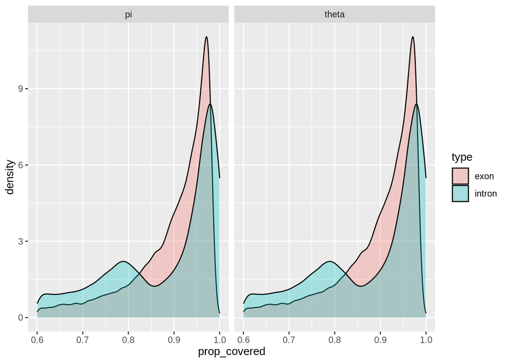

```r
# draw the distribution of prop. gene covered for exons and introns
ggplot(data_exon_intron, aes(prop_covered, fill = type)) +
  geom_density(alpha = .3) +
  facet_grid(~measure)
```

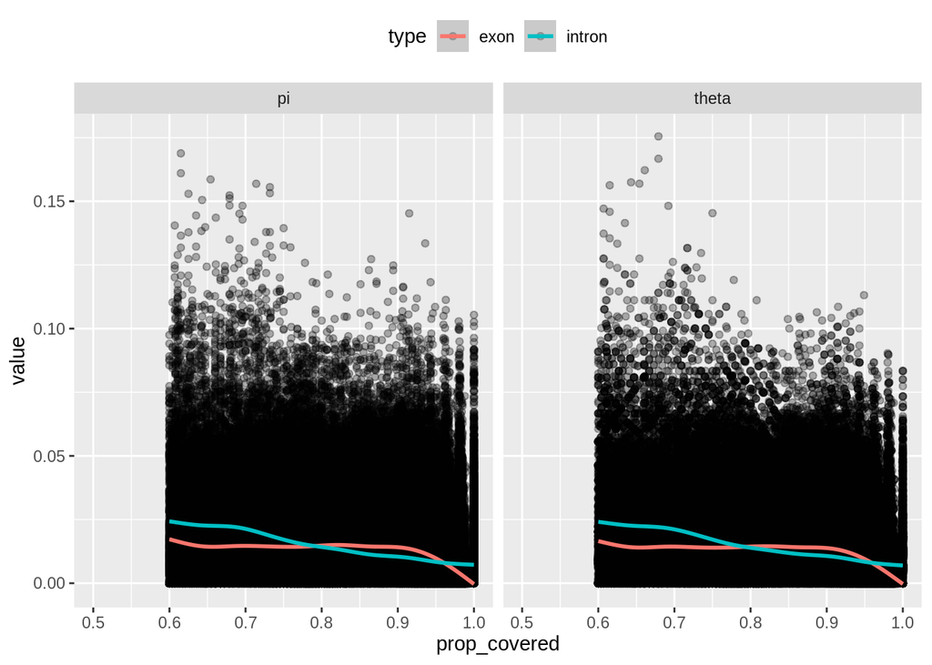

```r
# draw the prop. gene covered for exons and introns vs value
data_exon_intron %>%
  filter(measure != "d") %>% # remove d
ggplot(aes(prop_covered, value)) +
  geom_point(aes(fill = type),alpha = .3) +
  geom_smooth(aes(prop_covered, value, color = type)) +
  facet_grid(~measure) +
  xlim(0.5, NA) +
  theme(legend.position = "top")
```

```r
# keep only genes which had sufficient coverage in all 16 samples
genes_sufficient_coverage_all_samples <- data_exon_intron %>%
  filter(measure != "d") %>% # remove d
  filter(prop_covered >= 0.6) %>%
  group_by(gene, type, measure) %>%
  tally() %>%
  # keep only genes with sufficient coverage in all 16 samples- based only on exons
  filter(type == "exon" & n == 16 | type == "intron")
```

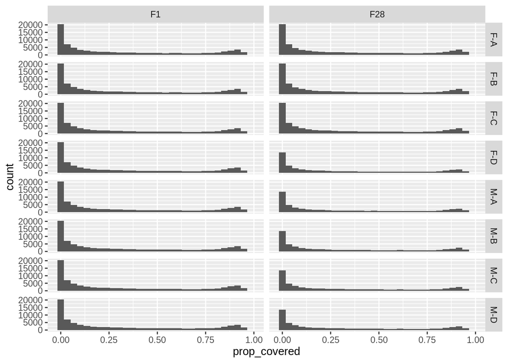

```r
# draw the distribution of proportion of window with sufficient coverage
windowed_pi_d_theta %>%
  ggplot(aes(prop_covered)) +
  geom_histogram() +
  facet_grid(line ~ generation)
```

```r
windowed_pi_d_theta <- windowed_pi_d_theta %>%
  filter(prop_covered >= 0.6)

### check if the same number of windows is compared between the samples
  # no, e.g. LG1 1850000 - only in few samples the threshold has been reached.

# make a list of windows which have sufficient coverage in all 8 samples in both generations
  # pi
windows_allSamples_allGenerations_pi <- windowed_pi_d_theta %>%
  filter(measure == "pi") %>%
  group_by(LG, window_pos) %>%
  tally() %>%
  filter(n == 16) %>%
  select(-n) %>%
  mutate(window_id = paste0(LG, "_", window_pos))

  # theta
windows_allSamples_allGenerations_theta <- windowed_pi_d_theta %>%
  filter(measure == "theta") %>%
  group_by(LG, window_pos) %>%
  tally() %>%
  filter(n == 16) %>%
  select(-n) %>%
  mutate(window_id = paste0(LG, "_", window_pos))

  # make window id variable
windowed_pi_d_theta <- windowed_pi_d_theta %>%
  mutate(window_id = paste0(LG, "_", window_pos))

windowed_pi_filtered_allSamples <- windowed_pi_d_theta %>%
  filter(measure == "pi") %>%
  filter(window_id %in% windows_allSamples_allGenerations_pi$window_id)

windowed_theta_filtered_allSamples <- windowed_pi_d_theta %>%
  filter(measure == "theta") %>%
  filter(window_id %in% windows_allSamples_allGenerations_theta$window_id)
```

```r
  # exons
pi_exon_mean_line <- data_exon_intron %>%
  filter(gene %in% genes_sufficient_coverage_all_samples$gene) %>%
  filter(measure == "pi" & type == "exon") %>%
  group_by(treatment, line, generation) %>%
  summarise(mean_pi = mean(value, na.rm = T)) %>%
  mutate(gen_treatment = paste(generation, treatment, sep = "_"))
pi_exon_mean <- pi_exon_mean_line %>%
    group_by(treatment, generation) %>%
    summarise(mean_pi_gen = mean(mean_pi),
    sd_pi = sd(mean_pi),
    n = n(),
    se_pi = sd_pi / sqrt(n))
```

```r
pi_exon_plot <- ggplot(pi_exon_mean, aes(generation, mean_pi_gen, color = treatment)) +
  geom_pointrange(aes(ymin = mean_pi_gen - sd_pi, ymax = mean_pi_gen + sd_pi),
                 position = position_dodge(width = 0.5), linewidth = 1.4) +
    geom_errorbar(aes(ymin = mean_pi_gen - sd_pi, ymax = mean_pi_gen + sd_pi),
                width = 0.1, position = position_dodge(width = 0.5)) +
  geom_point(data = pi_exon_mean_line, aes(generation, mean_pi, color = treatment),
             alpha = 0.5, position = position_jitterdodge(jitter.width = 0.2, dodge.width = 0.6, seed = 12345), size = 3) +
    geom_label_repel(data = pi_exon_mean_line, aes(generation, mean_pi, label = line, color = treatment),
                   position = position_jitterdodge(jitter.width = 0.2, dodge.width = 0.6, seed = 12345), size = 3, fill = NA) +
  theme_bw() +
  theme(legend.position = "none",
        legend.title = element_blank()) +
  scale_color_manual(values = c("#67AC55", "#F97A69")) +
  labs(y = expression(pi ~ "exon"))

print(pi_exon_plot)
```

[figure not shown]

```
model <- aov(mean_pi ~ treatment * generation, data = pi_exon_mean_line)
summary(model)
```

```
##                      Df   Sum Sq  Mean Sq F value   Pr(>F)
## treatment             1 8.61e-09 8.61e-09   4.785   0.0492 *
## generation            1 1.85e-07 1.85e-07 102.747 3.09e-07 ***
## treatment:generation  1 8.98e-09 8.98e-09   4.989   0.0453 *
## Residuals            12 2.16e-08 1.80e-09
## ---
## Signif. codes:  0 '***' 0.001 '**' 0.01 '*' 0.05 '.' 0.1 ' ' 1
```

```r
interaction_levels <- with(pi_exon_mean_line, interaction(treatment, generation))
post_hoc_results <- pairwise.t.test(pi_exon_mean_line$mean_pi, interaction_levels, p.adjust.method = "bonferroni")
```

```r
# introns
pi_intron_mean_line <- data_exon_intron %>%
  filter(measure == "pi" & type == "intron") %>%
  filter(gene %in% genes_sufficient_coverage_all_samples$gene) %>%
  group_by(treatment, line, generation) %>%
  summarise(mean_pi = mean(value, na.rm = T)) %>%
  mutate(gen_treatment = paste(generation, treatment, sep = "_"))
pi_intron_mean <- pi_intron_mean_line %>%
    group_by(treatment, generation) %>%
    summarise(mean_pi_gen = mean(mean_pi),
    sd_pi = sd(mean_pi),
    n = n(),
    se_pi = sd_pi / sqrt(n))
```

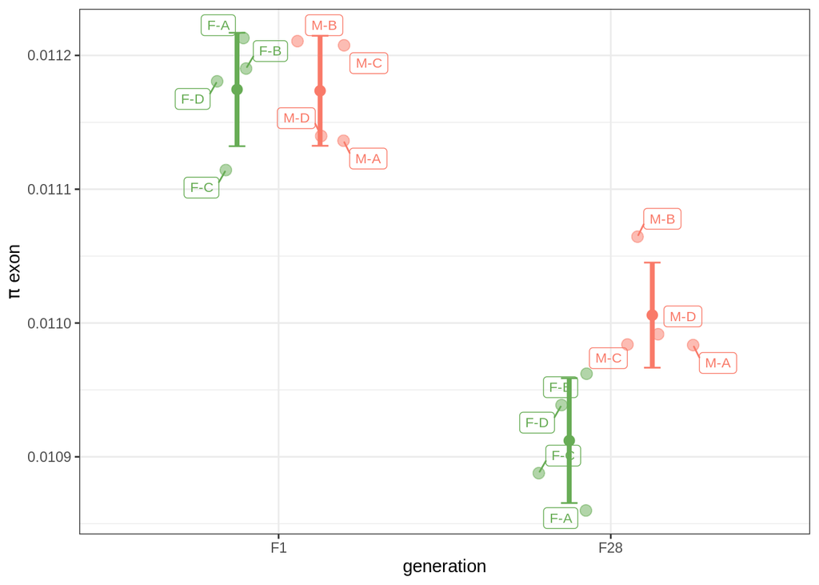

```r
pi_intron_plot <- ggplot(pi_intron_mean, aes(generation, mean_pi_gen, color = treatment)) +
  geom_pointrange(aes(ymin = mean_pi_gen - sd_pi, ymax = mean_pi_gen + sd_pi),
                 position = position_dodge(width = 0.5), linewidth = 1.4) +
    geom_errorbar(aes(ymin = mean_pi_gen - sd_pi, ymax = mean_pi_gen + sd_pi),
                width = 0.1, position = position_dodge(width = 0.5)) +
  geom_point(data = pi_intron_mean_line, aes(generation, mean_pi, color = treatment),
             alpha = 0.5, position = position_jitterdodge(jitter.width = 0.2, dodge.width = 0.6, seed = 12345), size = 3) +
  geom_label_repel(data = pi_intron_mean_line, aes(generation, mean_pi, label = line, color = treatment),
                  position = position_jitterdodge(jitter.width = 0.2, dodge.width = 0.6, seed = 12345), size = 3, fill = NA) +
  theme_bw() +
  theme(legend.position = "none",
        legend.title = element_blank()) +
  scale_color_manual(values = c("#67AC55", "#F97A69")) +
  labs(y = expression(pi ~ "intron"))

print(pi_exon_plot)
```

```r
model <- aov(mean_pi ~ treatment * generation, data = pi_intron_mean_line)
summary(model)
```

```
##                      Df    Sum Sq   Mean Sq F value Pr(>F)
## treatment             1 1.474e-08 1.474e-08   2.360  0.150
## generation            1 1.074e-08 1.074e-08   1.720  0.214
## treatment:generation  1 4.488e-08 4.488e-08   7.187  0.020 *
## Residuals            12 7.494e-08 6.250e-09
## ---
## Signif. codes:  0 '***' 0.001 '**' 0.01 '*' 0.05 '.' 0.1 ' ' 1
```

```r
interaction_levels <- with(pi_intron_mean_line, interaction(treatment, generation))
post_hoc_results <- pairwise.t.test(pi_intron_mean_line$mean_pi, interaction_levels, p.adjust.method = "bonferroni")
print(post_hoc_results)
```

```
##
##  Pairwise comparisons using t tests with pooled SD
##
## data:  pi_intron_mean_line$mean_pi and interaction_levels
##
##                   female-biased.F1 male_biased.F1 female-biased.F28
## male_biased.F1    1.000            -              -
## female-biased.F28 0.092            0.402          -
## male_biased.F28   1.000            1.000          0.069
##
## P value adjustment method: bonferroni
```

```r
# exons
theta_exon_mean_line <- data_exon_intron %>%
  filter(measure == "theta" & type == "exon") %>%
  filter(gene %in% genes_sufficient_coverage_all_samples$gene) %>%
  group_by(treatment, line, generation) %>%
  summarise(mean_theta = mean(value, na.rm = T)) %>%
  mutate(gen_treatment = paste(generation, treatment, sep = "_"))
theta_exon_mean <- theta_exon_mean_line %>%
    group_by(treatment, generation) %>%
    summarise(mean_theta_gen = mean(mean_theta),
    sd_theta = sd(mean_theta),
    n = n(),
    se_theta = sd_theta / sqrt(n))
```

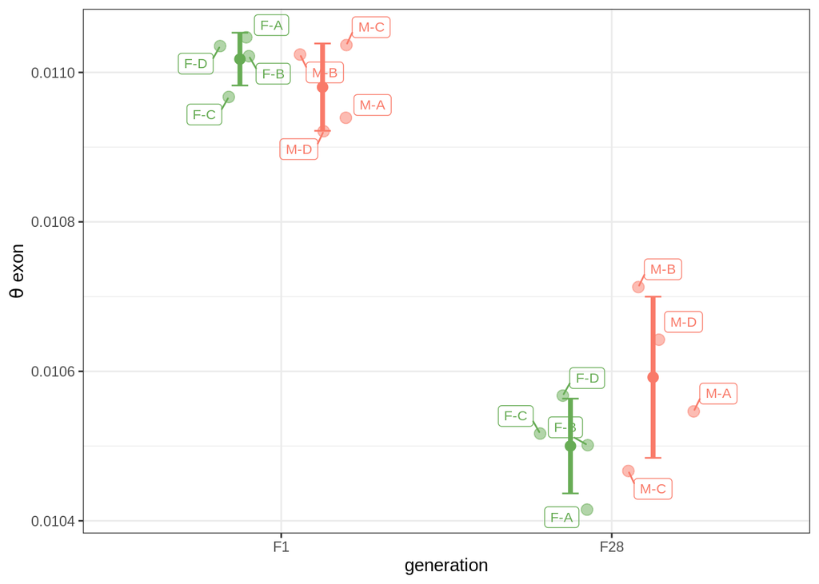

```r
theta_exon_plot <-  ggplot(theta_exon_mean, aes(generation, mean_theta_gen, color = treatment)) +
  geom_pointrange(aes(ymin = mean_theta_gen - sd_theta, ymax = mean_theta_gen + sd_theta),
                 position = position_dodge(width = 0.5), linewidth = 1.4) +
    geom_errorbar(aes(ymin = mean_theta_gen - sd_theta, ymax = mean_theta_gen + sd_theta),
                width = 0.1, position = position_dodge(width = 0.5)) +
  geom_point(data = theta_exon_mean_line, aes(generation, mean_theta, color = treatment),
             alpha = 0.5, position = position_jitterdodge(jitter.width = 0.2, dodge.width = 0.6, seed = 12345), size = 3) +
    geom_label_repel(data = theta_exon_mean_line, aes(generation, mean_theta, label = line, color = treatment),
                   position = position_jitterdodge(jitter.width = 0.2, dodge.width = 0.6, seed = 12345), size = 3, fill = NA) +
  theme_bw() +
  theme(legend.position = "none",
        legend.title = element_blank()) +
  scale_color_manual(values = c("#67AC55", "#F97A69")) +
  labs(y = expression(theta ~ "exon"))

plot(theta_exon_plot)
```

```r
model <- aov(mean_theta ~ treatment * generation, data = theta_exon_mean_line)
summary(model)
```

```
##                      Df    Sum Sq   Mean Sq F value   Pr(>F)
## treatment             1 3.000e-09 3.000e-09   0.584   0.4596
## generation            1 8.207e-07 8.207e-07 161.616 2.54e-08 ***
## treatment:generation  1 1.680e-08 1.680e-08   3.302   0.0942 .
## Residuals            12 6.090e-08 5.100e-09
## ---
## Signif. codes:  0 '***' 0.001 '**' 0.01 '*' 0.05 '.' 0.1 ' ' 1
```

```r
interaction_levels <- with(theta_exon_mean_line, interaction(treatment, generation))
post_hoc_results <- pairwise.t.test(theta_exon_mean_line$mean_theta, interaction_levels, p.adjust.method = "bonferroni")
print(post_hoc_results)
```

```
##
##  Pairwise comparisons using t tests with pooled SD
##
## data:  theta_exon_mean_line$mean_theta and interaction_levels
##
##                   female-biased.F1 male_biased.F1 female-biased.F28
## male_biased.F1    1.00             -              -
## female-biased.F28 1.6e-06          3.6e-06        -
## male_biased.F28   1.3e-05          3.3e-05        0.56
##
## P value adjustment method: bonferroni
```

```r
theta_intron_mean_line <- data_exon_intron %>%
  filter(gene %in% genes_sufficient_coverage_all_samples$gene) %>%
  filter(measure == "theta" & type == "intron") %>%
  group_by(treatment, line, generation) %>%
  summarise(mean_theta = mean(value, na.rm = T)) %>%
  mutate(gen_treatment = paste(generation, treatment, sep = "_"))
theta_intron_mean <- theta_intron_mean_line %>%
    group_by(treatment, generation) %>%
    summarise(mean_theta_gen = mean(mean_theta),
    sd_theta = sd(mean_theta),
    n = n(),
    se_theta = sd_theta / sqrt(n))
```

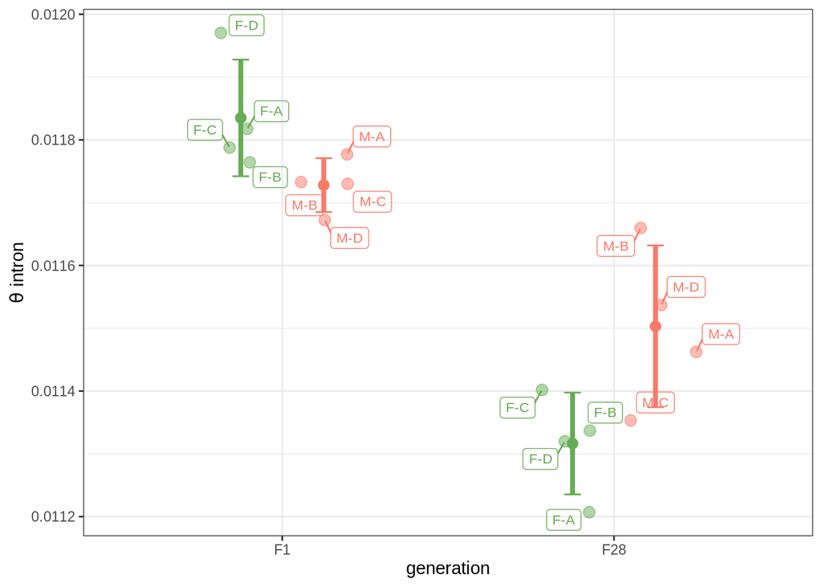

```r
theta_intron_plot <-  ggplot(theta_intron_mean, aes(generation, mean_theta_gen, color = treatment)) +
  geom_pointrange(aes(ymin = mean_theta_gen - sd_theta, ymax = mean_theta_gen + sd_theta),
                 position = position_dodge(width = 0.5), linewidth = 1.4) +
    geom_errorbar(aes(ymin = mean_theta_gen - sd_theta, ymax = mean_theta_gen + sd_theta),
                width = 0.1, position = position_dodge(width = 0.5)) +
  geom_point(data = theta_intron_mean_line, aes(generation, mean_theta, color = treatment),
             alpha = 0.5, position = position_jitterdodge(jitter.width = 0.2, dodge.width = 0.6, seed = 12345), size = 3) +
    geom_label_repel(data = theta_intron_mean_line, aes(generation, mean_theta, label = line, color = treatment),
                   position = position_jitterdodge(jitter.width = 0.2, dodge.width = 0.6, seed = 12345), size = 3, fill = NA) +
  theme_bw() +
  theme(legend.position = "none",
        legend.title = element_blank()) +
  scale_color_manual(values = c("#67AC55", "#F97A69")) +
  labs(y = expression(theta ~ "intron"))

plot(theta_intron_plot)
```

```r
model <- aov(mean_theta ~ treatment * generation, data = theta_intron_mean_line)
summary(model)
```

```
##                      Df    Sum Sq   Mean Sq F value   Pr(>F)
## treatment             1 6.300e-09 6.300e-09   0.755   0.4019
## generation            1 5.527e-07 5.527e-07  65.746 3.28e-06 ***
## treatment:generation  1 8.620e-08 8.620e-08  10.254   0.0076 **
## Residuals            12 1.009e-07 8.400e-09
## ---
## Signif. codes:  0 '***' 0.001 '**' 0.01 '*' 0.05 '.' 0.1 ' ' 1
```

```r
interaction_levels <- with(theta_intron_mean_line, interaction(treatment, generation))
post_hoc_results <- pairwise.t.test(theta_intron_mean_line$mean_theta, interaction_levels, p.adjust.method = "bonferroni")
print(post_hoc_results)
```

```
##
##  Pairwise comparisons using t tests with pooled SD
##
## data:  theta_intron_mean_line$mean_theta and interaction_levels
##
##                   female-biased.F1 male_biased.F1 female-biased.F28
## male_biased.F1    0.74941          -              -
## female-biased.F28 2.3e-05          0.00022        -
## male_biased.F28   0.00152          0.02783        0.08317
##
## P value adjustment method: bonferroni
```

```r
pi_mean_line <- windowed_pi_filtered_allSamples %>%
  filter(measure == "pi") %>%
  group_by(treatment, line, generation) %>%
  summarise(mean_pi = mean(value, na.rm = T)) %>%
  mutate(gen_treatment = paste(generation, treatment, sep = "_"))
pi_mean <- pi_mean_line %>%
    group_by(treatment, generation) %>%
    summarise(mean_pi_gen = mean(mean_pi),
    sd_pi = sd(mean_pi),
    n = n(),
    se_pi = sd_pi / sqrt(n))
```

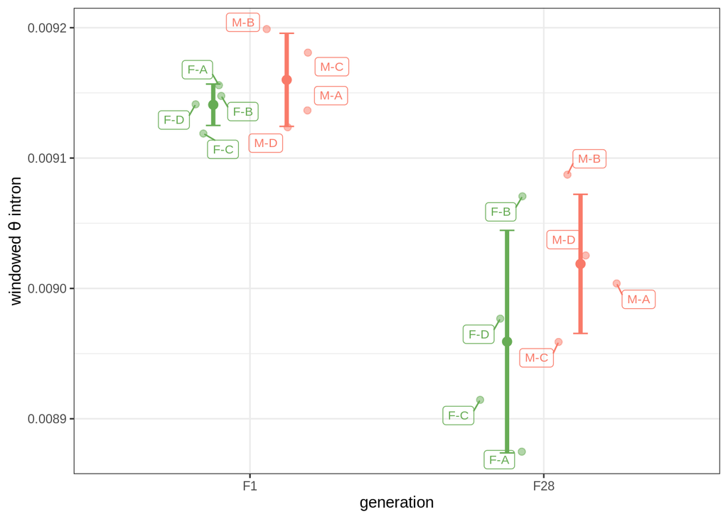

```r
pi_windowed_plot <-  ggplot(pi_mean, aes(generation, mean_pi_gen, color = treatment)) +
  geom_pointrange(aes(ymin = mean_pi_gen - sd_pi, ymax = mean_pi_gen + sd_pi),
                 position = position_dodge(width = 0.5), linewidth = 1.4) +
    geom_errorbar(aes(ymin = mean_pi_gen - sd_pi, ymax = mean_pi_gen + sd_pi),
                width = 0.1, position = position_dodge(width = 0.5)) +
  geom_point(data = pi_mean_line, aes(generation, mean_pi, color = treatment),
             alpha = .5, position = position_jitterdodge(jitter.width = 0.2, dodge.width = 0.6, seed = 12345), size = 2) +
    geom_label_repel(data = pi_mean_line, aes(generation, mean_pi, label = line, color = treatment),
                   position = position_jitterdodge(jitter.width = 0.2, dodge.width = 0.6, seed = 12345), size = 3, fill = NA) +
  theme_bw() +
  theme(legend.position = "none",
        legend.title = element_blank()) +
  scale_color_manual(values = c("#67AC55", "#F97A69")) +
  labs(y = expression("windowed" ~ theta ~ "intron"))

plot(pi_windowed_plot)
```

```r
theta_mean_line <- windowed_theta_filtered_allSamples %>%
  group_by(treatment, line, generation) %>%
  filter(measure == "theta") %>%
  summarise(mean_theta = mean(value, na.rm = T)) %>%
  mutate(gen_treatment = paste(generation, treatment, sep = "_"))
theta_mean <- theta_mean_line %>%
    group_by(treatment, generation) %>%
    summarise(mean_theta_gen = mean(mean_theta),
    sd_theta = sd(mean_theta),
    n = n(),
    se_theta = sd_theta / sqrt(n))
```

[figure not shown]

```r
ggplot(theta_mean, aes(generation, mean_theta_gen, color = treatment)) +
  geom_pointrange(aes(ymin = mean_theta_gen - sd_theta, ymax = mean_theta_gen + sd_theta),
                  position = position_dodge(width = 0.5), linewidth = 1.4) +
  geom_point(data = theta_mean_line, aes(generation, mean_theta, color = treatment),
             alpha = .5, position = position_jitterdodge(jitter.width = 0.1, dodge.width = 0.5, seed = 1234), size = 2) +
  geom_label_repel(data = theta_mean_line, aes(generation, mean_theta, label = line, color = treatment),
                  position = position_jitterdodge(jitter.width = 0.1, dodge.width = 0.5, seed = 1234), size = 3, fill = NA) +
  theme_bw() +
  theme(legend.position = "top") +
  ggtitle("Mean  theta, 10 kb windows", subtitle = "all windows had to have prop_cov > 0.6 in all samples in both generations")
```

[figure not shown]

```r
theta_windowed_plot <-  ggplot(theta_mean, aes(generation, mean_theta_gen, color = treatment)) +
  geom_pointrange(aes(ymin = mean_theta_gen - sd_theta, ymax = mean_theta_gen + sd_theta),
                 position = position_dodge(width = 0.5), linewidth = 1.4) +
    geom_errorbar(aes(ymin = mean_theta_gen - sd_theta, ymax = mean_theta_gen + sd_theta),
                width = 0.1, position = position_dodge(width = 0.5)) +
  geom_point(data = theta_mean_line, aes(generation, mean_theta, color = treatment),
             alpha = .5, position = position_jitterdodge(jitter.width = 0.2, dodge.width = 0.6, seed = 12345), size = 2) +
    geom_label_repel(data = theta_mean_line, aes(generation, mean_theta, label = line, color = treatment),
                   position = position_jitterdodge(jitter.width = 0.2, dodge.width = 0.6, seed = 12345), size = 3, fill = NA) +
  theme_bw() +
  theme(legend.position = "none",
        legend.title = element_blank()) +
  scale_color_manual(values = c("#67AC55", "#F97A69")) +
  labs(y = expression("windowed" ~ theta ~ "intron"))

plot(theta_windowed_plot)
```

```r
# filter the genes: all genes ahve to be present in all 16 samples
data_synNonsym %>%
  filter(gene %in% genes_sufficient_coverage_all_samples$gene) %>%
  filter(measure == "pi") %>%
  group_by(gene) %>%
  tally()
```

```
## # A tibble: 11,916 × 2
##    gene              n
##    <chr>         <int>
##  1 rhrob01g00380    16
##  2 rhrob01g00400    16
##  3 rhrob01g00470    16
##  4 rhrob01g00500    16
##  5 rhrob01g00550    16
##  6 rhrob01g00570    16
##  7 rhrob01g00580    16
##  8 rhrob01g00710    16
##  9 rhrob01g00730    16
## 10 rhrob01g00740    16
## # ℹ 11,906 more rows
```

```r
# synonymous pi
pi_syn_mean_line <- data_synNonsym %>%
  filter(measure == "pi") %>%
  filter(gene %in% genes_sufficient_coverage_all_samples$gene) %>%
  group_by(treatment, line, generation) %>%
  summarise(mean_pi_syn = mean(S.measure, na.rm = T)) %>%
  mutate(gen_treatment = paste(generation, treatment, sep = "_"))
pi_syn_mean <- pi_syn_mean_line %>%
    group_by(treatment, generation) %>%
    summarise(mean_pi_syn_gen = mean(mean_pi_syn),
    sd_pi = sd(mean_pi_syn),
    n = n(),
    se_pi = sd_pi / sqrt(n),
    ci_lower = mean_pi_syn_gen - qt(0.95, df = n-1) * se_pi,
    ci_upper = mean_pi_syn_gen + qt(0.95, df = n-1) * se_pi)
```

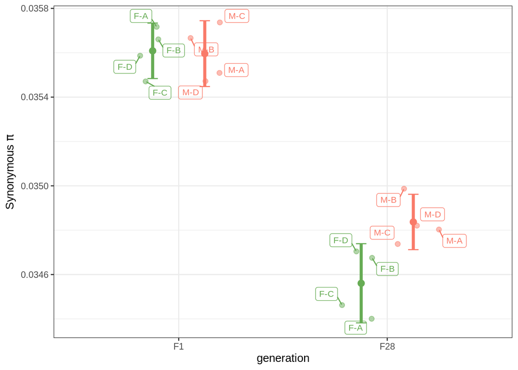

```r
pi_syn_plot <-  ggplot(pi_syn_mean, aes(generation, mean_pi_syn_gen, color = treatment)) +
  geom_pointrange(aes(ymin = ci_lower, ymax = ci_upper),
                 position = position_dodge(width = 0.5), linewidth = 1.4) +
    geom_errorbar(aes(ymin = ci_lower, ymax = ci_upper),
                width = 0.1, position = position_dodge(width = 0.5)) +
  geom_point(data = pi_syn_mean_line, aes(generation, mean_pi_syn, color = treatment),
             alpha = .5, position = position_jitterdodge(jitter.width = 0.2, dodge.width = 0.6, seed = 12345), size = 2) +
    geom_label_repel(data = pi_syn_mean_line, aes(generation, mean_pi_syn, label = line, color = treatment),
                   position = position_jitterdodge(jitter.width = 0.2, dodge.width = 0.6, seed = 12345), size = 3, fill = NA) +
  theme_bw() +
  theme(legend.position = "none",
        legend.title = element_blank()) +
  scale_color_manual(values = c("#67AC55", "#F97A69")) +
  labs(y = expression("Synonymous" ~ pi))


plot(pi_syn_plot)
```

```r
model <- aov(mean_pi_syn ~ treatment * generation, data = pi_syn_mean_line)
summary(model)
```

```
##                      Df    Sum Sq   Mean Sq F value   Pr(>F)
## treatment             1 7.000e-08 7.000e-08   4.527   0.0548 .
## generation            1 3.266e-06 3.266e-06 212.515 5.38e-09 ***
## treatment:generation  1 8.400e-08 8.400e-08   5.442   0.0379 *
## Residuals            12 1.840e-07 1.500e-08
## ---
## Signif. codes:  0 '***' 0.001 '**' 0.01 '*' 0.05 '.' 0.1 ' ' 1
```

```r
interaction_levels <- with(pi_syn_mean_line, interaction(treatment, generation))
post_hoc_results <- pairwise.t.test(pi_syn_mean_line$mean_pi_syn, interaction_levels, p.adjust.method = "bonferroni")
print(post_hoc_results)
```

```
##
##  Pairwise comparisons using t tests with pooled SD
##
## data:  pi_syn_mean_line$mean_pi_syn and interaction_levels
##
##                   female-biased.F1 male_biased.F1 female-biased.F28
## male_biased.F1    1.00             -              -
## female-biased.F28 3.0e-07          3.5e-07        -
## male_biased.F28   8.4e-06          9.9e-06        0.05
##
## P value adjustment method: bonferroni
```

```r
# synonymous pi
pi_nonSyn_mean_line <- data_synNonsym %>%
  filter(measure == "pi") %>%
  filter(gene %in% genes_sufficient_coverage_all_samples$gene) %>%
  group_by(treatment, line, generation) %>%
  summarise(mean_pi_nonSyn = mean(NS.measure, na.rm = T)) %>%
  mutate(gen_treatment = paste(generation, treatment, sep = "_"))
pi_nonSyn_mean <- pi_nonSyn_mean_line %>%
    group_by(treatment, generation) %>%
    summarise(mean_pi_nonSyn_gen = mean(mean_pi_nonSyn),
    sd_pi = sd(mean_pi_nonSyn),
    n = n(),
    se_pi = sd_pi / sqrt(n),
    ci_lower = mean_pi_nonSyn_gen - qt(0.95, df = n-1) * se_pi,
    ci_upper = mean_pi_nonSyn_gen + qt(0.95, df = n-1) * se_pi)
```

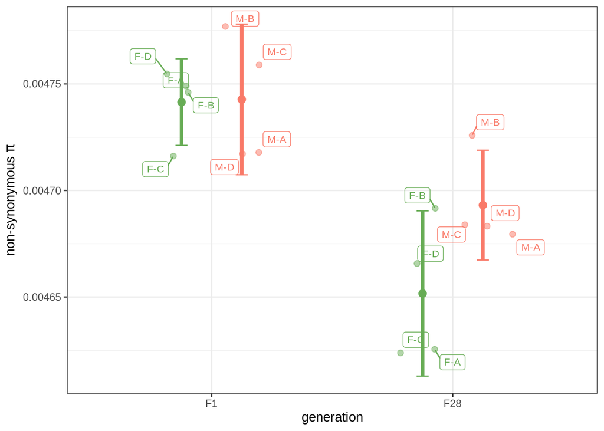

```r
pi_nonSyn_plot <-  ggplot(pi_nonSyn_mean, aes(generation, mean_pi_nonSyn_gen, color = treatment)) +
  geom_pointrange(aes(ymin = ci_lower, ymax = ci_upper),
                 position = position_dodge(width = 0.5), linewidth = 1.4) +
    geom_errorbar(aes(ymin = ci_lower, ymax = ci_upper),
                width = 0.1, position = position_dodge(width = 0.5)) +
  geom_point(data = pi_nonSyn_mean_line, aes(generation, mean_pi_nonSyn, color = treatment),
             alpha = .5, position = position_jitterdodge(jitter.width = 0.2, dodge.width = 0.6, seed = 12345), size = 2) +
    geom_label_repel(data = pi_nonSyn_mean_line, aes(generation, mean_pi_nonSyn, label = line, color = treatment),
                   position = position_jitterdodge(jitter.width = 0.2, dodge.width = 0.6, seed = 12345), size = 3, fill = NA) +
  theme_bw() +
  theme(legend.position = "none",
        legend.title = element_blank()) +
  scale_color_manual(values = c("#67AC55", "#F97A69")) +
  labs(y = expression("non-synonymous" ~ pi))


plot(pi_nonSyn_plot)
```

```r
model <- aov(mean_pi_nonSyn ~ treatment * generation, data = pi_nonSyn_mean_line)
summary(model)
```

```
##                      Df    Sum Sq   Mean Sq F value   Pr(>F)
## treatment             1 1.827e-09 1.827e-09   2.643 0.129977
## generation            1 1.944e-08 1.944e-08  28.127 0.000187 ***
## treatment:generation  1 1.618e-09 1.618e-09   2.340 0.151987
## Residuals            12 8.295e-09 6.910e-10
## ---
## Signif. codes:  0 '***' 0.001 '**' 0.01 '*' 0.05 '.' 0.1 ' ' 1
```

```r
interaction_levels <- with(pi_nonSyn_mean_line, interaction(treatment, generation))
post_hoc_results <- pairwise.t.test(pi_nonSyn_mean_line$mean_pi_nonSyn, interaction_levels, p.adjust.method = "bonferroni")
print(post_hoc_results)
```

```
##
##  Pairwise comparisons using t tests with pooled SD
##
## data:  pi_nonSyn_mean_line$mean_pi_nonSyn and interaction_levels
##
##                   female-biased.F1 male_biased.F1 female-biased.F28
## male_biased.F1    1.0000           -              -
## female-biased.F28 0.0025           0.0022         -
## male_biased.F28   0.1392           0.1228         0.2730
##
## P value adjustment method: bonferroni
```

```r
# synonymous theta
theta_syn_mean_line <- data_synNonsym %>%
  filter(measure == "theta") %>%
  filter(gene %in% genes_sufficient_coverage_all_samples$gene) %>%
  group_by(treatment, line, generation) %>%
  summarise(mean_theta_syn = mean(S.measure, na.rm = T)) %>%
  mutate(gen_treatment = paste(generation, treatment, sep = "_"))
theta_syn_mean <- theta_syn_mean_line %>%
    group_by(treatment, generation) %>%
    summarise(mean_theta_syn_gen = mean(mean_theta_syn),
    sd_theta = sd(mean_theta_syn),
    n = n(),
    se_theta = sd_theta / sqrt(n),
    ci_lower = mean_theta_syn_gen - qt(0.95, df = n-1) * se_theta,
    ci_upper = mean_theta_syn_gen + qt(0.95, df = n-1) * se_theta)
```

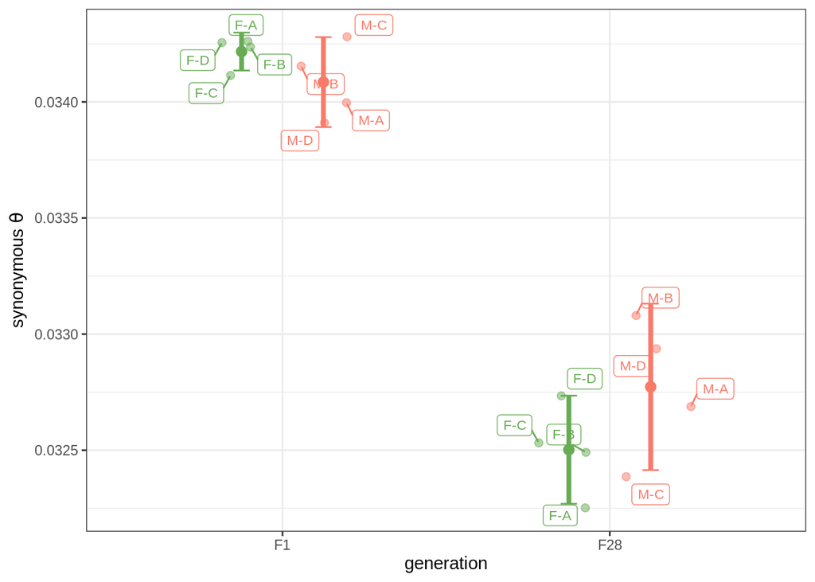

```r
syn_theta_plot <-  ggplot(theta_syn_mean, aes(generation, mean_theta_syn_gen, color = treatment)) +
  geom_pointrange(aes(ymin = ci_lower, ymax = ci_upper),
                 position = position_dodge(width = 0.5), linewidth = 1.4) +
    geom_errorbar(aes(ymin = ci_lower, ymax = ci_upper),
                width = 0.1, position = position_dodge(width = 0.5)) +
  geom_point(data = theta_syn_mean_line, aes(generation, mean_theta_syn, color = treatment),
             alpha = .5, position = position_jitterdodge(jitter.width = 0.2, dodge.width = 0.6, seed = 12345), size = 2) +
    geom_label_repel(data = theta_syn_mean_line, aes(generation, mean_theta_syn, label = line, color = treatment),
                   position = position_jitterdodge(jitter.width = 0.2, dodge.width = 0.6, seed = 12345), size = 3, fill = NA) +
  theme_bw() +
  theme(legend.position = "none",
        legend.title = element_blank()) +
  scale_color_manual(values = c("#67AC55", "#F97A69")) +
  labs(y = expression("synonymous" ~ theta))


plot(syn_theta_plot)
```

```r
model <- aov(mean_theta_syn ~ treatment * generation, data = theta_syn_mean_line)
summary(model)
```

```
##                      Df    Sum Sq   Mean Sq F value   Pr(>F)
## treatment             1 1.900e-08 1.900e-08   0.475   0.5039
## generation            1 9.164e-06 9.164e-06 223.709 4.02e-09 ***
## treatment:generation  1 1.620e-07 1.620e-07   3.952   0.0701 .
## Residuals            12 4.920e-07 4.100e-08
## ---
## Signif. codes:  0 '***' 0.001 '**' 0.01 '*' 0.05 '.' 0.1 ' ' 1
```

```r
interaction_levels <- with(theta_syn_mean_line, interaction(treatment, generation))
post_hoc_results <- pairwise.t.test(theta_syn_mean_line$mean_theta_syn, interaction_levels, p.adjust.method = "bonferroni")
print(post_hoc_results)
```

```
##
##  Pairwise comparisons using t tests with pooled SD
##
## data:  theta_syn_mean_line$mean_theta_syn and interaction_levels
##
##                   female-biased.F1 male_biased.F1 female-biased.F28
## male_biased.F1    1.0              -              -
## female-biased.F28 3.0e-07          7.1e-07        -
## male_biased.F28   2.0e-06          5.4e-06        0.5
##
## P value adjustment method: bonferroni
```

```r
# synonymous theta
theta_nonSyn_mean_line <- data_synNonsym %>%
  filter(measure == "theta") %>%
  filter(gene %in% genes_sufficient_coverage_all_samples$gene) %>%
  group_by(treatment, line, generation) %>%
  summarise(mean_theta_nonSyn = mean(NS.measure, na.rm = T)) %>%
  mutate(gen_treatment = paste(generation, treatment, sep = "_"))
theta_nonSyn_mean <- theta_nonSyn_mean_line %>%
    group_by(treatment, generation) %>%
    summarise(mean_theta_nonSyn_gen = mean(mean_theta_nonSyn),
    sd_theta = sd(mean_theta_nonSyn),
    n = n(),
    se_theta = sd_theta / sqrt(n),
    ci_lower = mean_theta_nonSyn_gen - qt(0.95, df = n-1) * se_theta,
    ci_upper = mean_theta_nonSyn_gen + qt(0.95, df = n-1) * se_theta)
```

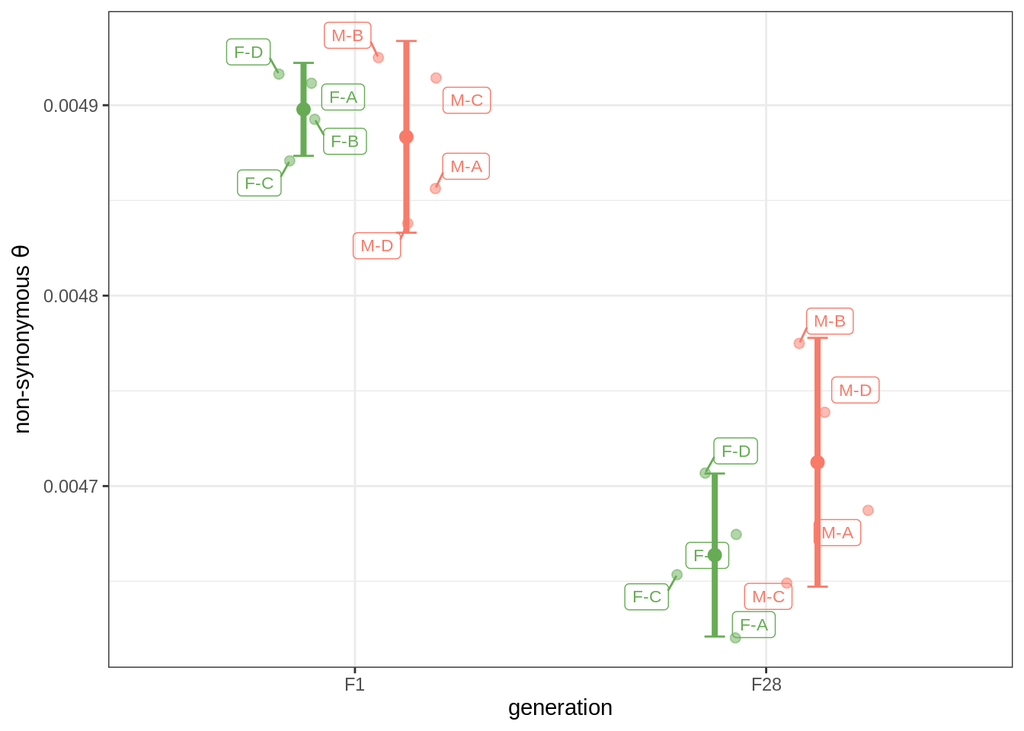

```r
theta_nonSym_plot <-  ggplot(theta_nonSyn_mean, aes(generation, mean_theta_nonSyn_gen, color = treatment)) +
  geom_pointrange(aes(ymin = ci_lower, ymax = ci_upper),
                 position = position_dodge(width = 0.5), linewidth = 1.4) +
    geom_errorbar(aes(ymin = ci_lower, ymax = ci_upper),
                width = 0.1, position = position_dodge(width = 0.5)) +
  geom_point(data = theta_nonSyn_mean_line, aes(generation, mean_theta_nonSyn, color = treatment),
             alpha = .5, position = position_jitterdodge(jitter.width = 0.2, dodge.width = 0.6, seed = 12345), size = 2) +
    geom_label_repel(data = theta_nonSyn_mean_line, aes(generation, mean_theta_nonSyn, label = line, color = treatment),
                   position = position_jitterdodge(jitter.width = 0.2, dodge.width = 0.6, seed = 12345), size = 3, fill = NA) +
  theme_bw() +
  theme(legend.position = "none",
        legend.title = element_blank()) +
  scale_color_manual(values = c("#67AC55", "#F97A69")) +
  labs(y = expression("non-synonymous" ~ theta))


plot(theta_nonSym_plot)
```

```r
model <- aov(mean_theta_nonSyn ~ treatment * generation, data = theta_nonSyn_mean_line)
summary(model)
```

```
##                      Df   Sum Sq  Mean Sq F value   Pr(>F)
## treatment             1 1.17e-09 1.17e-09   0.705    0.418
## generation            1 1.64e-07 1.64e-07  98.386 3.91e-07 ***
## treatment:generation  1 3.99e-09 3.99e-09   2.393    0.148
## Residuals            12 2.00e-08 1.67e-09
## ---
## Signif. codes:  0 '***' 0.001 '**' 0.01 '*' 0.05 '.' 0.1 ' ' 1
```

```r
interaction_levels <- with(theta_nonSyn_mean_line, interaction(treatment, generation))
post_hoc_results <- pairwise.t.test(theta_nonSyn_mean_line$mean_theta_nonSyn, interaction_levels, p.adjust.method = "bonferroni")
print(post_hoc_results)
```

```
##
##  Pairwise comparisons using t tests with pooled SD
##
## data:  theta_nonSyn_mean_line$mean_theta_nonSyn and interaction_levels
##
##                   female-biased.F1 male_biased.F1 female-biased.F28
## male_biased.F1    1.00000          -              -
## female-biased.F28 2.0e-05          3.8e-05        -
## male_biased.F28   0.00020          0.00042        0.70393
##
## P value adjustment method: bonferroni
```

Deltas:

1. delta PI:

Correct deltas according to NEE: instead of subtracting PI nonsyn - PI syn, subtract PI nonsyn - GW PI syn. I think it is not entirely correct, as in NS less genes are taken into account, because genes with 0 PI in F0 and F28 are removed- you cannot divide by zero. Also, there are genes with PI=0 in F28 and PI>0 in F1, so division gives 0. These genes are taken into account in syn PI.

More genes contribute to synonymous F28/F1, because it is not calculated gene-wise, but genome-wide, so genes with F28/F1 == Inf or == NA are contributiong to Syn F28/F1, but not to the NonSym F28/F1.

```r
# non-synonymous PI: comparison F28 to F1
pi_nonSyn_F28_F1 <- data_synNonsym %>%
  filter(measure == "pi") %>% # keep only PI
  filter(gene %in% genes_sufficient_coverage_all_samples$gene) %>%
  group_by(generation, line, treatment, gene) %>%
  select(generation, line, treatment, gene, NS.measure) %>% # here NS or S indicate non-syn or synonymous positions
  pivot_wider(id_cols = c(line, treatment, gene), # change fromat to wider
              names_from = generation,
              values_from = NS.measure,
              names_prefix = "pi_nonSym_") %>%
  mutate(pi_nonSym_F28_div_F1 = pi_nonSym_F28/pi_nonSym_F1,
         pi_nonSym_F28_div_F1_logPlus1 = log(pi_nonSym_F28_div_F1 + 1))

# remove infinite values from data
pi_nonSyn_F28_F1 <- pi_nonSyn_F28_F1 %>%
 filter(is.finite(pi_nonSym_F28_div_F1_logPlus1))


###  genome-wide synonymous diversity (remove genes excluded from NS)
  # calculate GW-mean PI for all synonymous sites (within each line)
pi_syn_F28_F1_GW <- data_synNonsym %>%
  filter(measure == "pi") %>% # keep only PI
  filter(gene %in% genes_sufficient_coverage_all_samples$gene) %>%
  group_by(generation, line, treatment) %>%
  summarise(avg_pi_line_gen = mean(S.measure)) %>%
  #select(generation, line, treatment, S.measure) %>%
  pivot_wider(id_cols = c(line, treatment), # change fromat to wider
              names_from = generation,
              values_from = avg_pi_line_gen,
              names_prefix = "GW_pi_sym_") %>%
  mutate(GW_pi_sym_F28_div_F1 = GW_pi_sym_F28/GW_pi_sym_F1,
         GW_pi_sym_F28_div_F1_logPlus1 = log(GW_pi_sym_F28_div_F1 + 1))
#### calculate delta with corrected Syn (GW), as in NEE:
delta_pi_synGW_nonSym <- pi_nonSyn_F28_F1 %>%
  left_join(pi_syn_F28_F1_GW[,c(1,6)], by = "line") %>%
  mutate(delta_NS_S = pi_nonSym_F28_div_F1_logPlus1 - GW_pi_sym_F28_div_F1_logPlus1,
         treatment = ifelse(str_detect(line, "^F"), "female-biased", "male-biased")) %>%
  group_by(line, treatment) %>%
  summarise(delta_NS_S = mean(delta_NS_S))
```

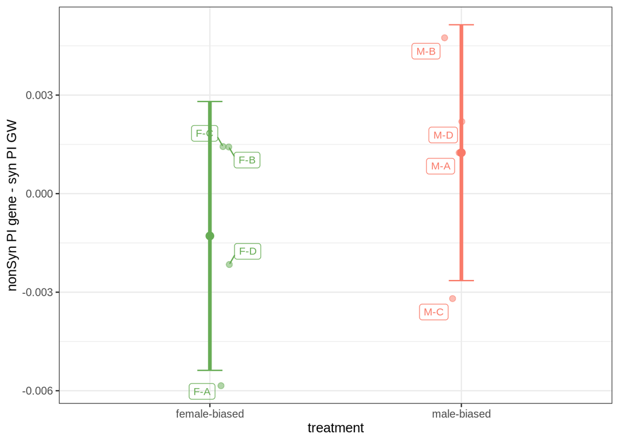

```r
# prepare mean non-sym across lines within treatment
delta_pi_synGW_nonSym_mean <- delta_pi_synGW_nonSym %>%
    group_by(treatment) %>%
    summarise(mean_delta_NS_S = mean(delta_NS_S),
    sd_delta = sd(delta_NS_S),
    n = n(),
    se_delta = sd_delta / sqrt(n),
    ci_lower = mean_delta_NS_S - qt(0.95, df = n-1) * se_delta,
    ci_upper = mean_delta_NS_S + qt(0.95, df = n-1) * se_delta)


delta_pi_plot <-  ggplot(delta_pi_synGW_nonSym_mean, aes(treatment, mean_delta_NS_S, color = treatment)) +
  geom_pointrange(aes(ymin = ci_lower, ymax = ci_upper),
                 position = position_dodge(width = 0.5), linewidth = 1.4) +
    geom_errorbar(aes(ymin = ci_lower, ymax = ci_upper),
                width = 0.1, position = position_dodge(width = 0.5)) +
  geom_point(data = delta_pi_synGW_nonSym, aes(treatment, delta_NS_S, color = treatment),
             alpha = .5, position = position_jitterdodge(jitter.width = 0.2, dodge.width = 0.6, seed = 12345), size = 2) +
    geom_label_repel(data = delta_pi_synGW_nonSym, aes(treatment, delta_NS_S, label = line, color = treatment),
                   position = position_jitterdodge(jitter.width = 0.2, dodge.width = 0.6, seed = 12345), size = 3, fill = NA) +
  theme_bw() +
  theme(legend.position = "none",
        legend.title = element_blank()) +
  scale_color_manual(values = c("#67AC55", "#F97A69")) +
  labs(y = "nonSyn PI gene - syn PI GW")

plot(delta_pi_plot)
```

```r
t.test(delta_NS_S ~ treatment, data = delta_pi_synGW_nonSym, var.equal = FALSE)
```

```
##
##  Welch Two Sample t-test
##
## data:  delta_NS_S by treatment
## t = -1.0558, df = 5.9853, p-value = 0.3318
## alternative hypothesis: true difference in means between group female-biased and group male-biased is not equal to 0
## 95 percent confidence interval:
##  -0.008410798  0.003342435
## sample estimates:
## mean in group female-biased   mean in group male-biased
##                -0.001287553                 0.001246629
```

```r
# non-synonymous theta: comparison F28 to F1
theta_nonSyn_F28_F1 <- data_synNonsym %>%
  filter(measure == "theta") %>% # keep only theta
  filter(gene %in% genes_sufficient_coverage_all_samples$gene) %>%
  group_by(generation, line, treatment, gene) %>%
  select(generation, line, treatment, gene, NS.measure) %>% # here NS or S indicate non-syn or synonymous positions
  pivot_wider(id_cols = c(line, treatment, gene), # change fromat to wider
              names_from = generation,
              values_from = NS.measure,
              names_prefix = "theta_nonSym_") %>%
  mutate(theta_nonSym_F28_div_F1 = theta_nonSym_F28/theta_nonSym_F1,
         theta_nonSym_F28_div_F1_logPlus1 = log(theta_nonSym_F28_div_F1 + 1))

# remove infinite values from data
theta_nonSyn_F28_F1 <- theta_nonSyn_F28_F1 %>%
 filter(is.finite(theta_nonSym_F28_div_F1_logPlus1))


###  genome-wide synonymous diversity (remove genes excluded from NS)
  # calculate GW-mean theta for all synonymous sites (within each line)
theta_syn_F28_F1_GW <- data_synNonsym %>%
  filter(measure == "theta") %>% # keep only theta
  filter(gene %in% genes_sufficient_coverage_all_samples$gene) %>%
  group_by(generation, line, treatment) %>%
  summarise(avg_theta_line_gen = mean(S.measure)) %>%
  #select(generation, line, treatment, S.measure) %>%
  pivot_wider(id_cols = c(line, treatment), # change fromat to wider
              names_from = generation,
              values_from = avg_theta_line_gen,
              names_prefix = "GW_theta_sym_") %>%
  mutate(GW_theta_sym_F28_div_F1 = GW_theta_sym_F28/GW_theta_sym_F1,
         GW_theta_sym_F28_div_F1_logPlus1 = log(GW_theta_sym_F28_div_F1 + 1))
#### calculate delta with corrected Syn (GW), as in NEE:
delta_theta_synGW_nonSym <- theta_nonSyn_F28_F1 %>%
  left_join(theta_syn_F28_F1_GW[,c(1,6)], by = "line") %>%
  mutate(delta_NS_S = theta_nonSym_F28_div_F1_logPlus1 - GW_theta_sym_F28_div_F1_logPlus1,
         treatment = ifelse(str_detect(line, "^F"), "female-biased", "male-biased")) %>%
  group_by(line, treatment) %>%
  summarise(delta_NS_S = mean(delta_NS_S))
```

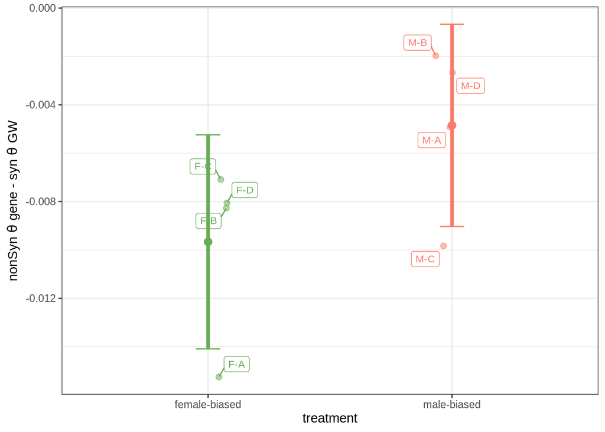

```r
# prepare mean non-sym across lines within treatment
delta_theta_synGW_nonSym_mean <- delta_theta_synGW_nonSym %>%
    group_by(treatment) %>%
    summarise(mean_delta_NS_S = mean(delta_NS_S),
    sd_delta = sd(delta_NS_S),
    n = n(),
    se_delta = sd_delta / sqrt(n),
    ci_lower = mean_delta_NS_S - qt(0.95, df = n-1) * se_delta,
    ci_upper = mean_delta_NS_S + qt(0.95, df = n-1) * se_delta)


delta_theta_plot <-  ggplot(delta_theta_synGW_nonSym_mean, aes(treatment, mean_delta_NS_S, color = treatment)) +
  geom_pointrange(aes(ymin = ci_lower, ymax = ci_upper),
                 position = position_dodge(width = 0.5), linewidth = 1.4) +
    geom_errorbar(aes(ymin = ci_lower, ymax = ci_upper),
                width = 0.1, position = position_dodge(width = 0.5)) +
  geom_point(data = delta_theta_synGW_nonSym, aes(treatment, delta_NS_S, color = treatment),
             alpha = .5, position = position_jitterdodge(jitter.width = 0.2, dodge.width = 0.6, seed = 12345), size = 2) +
    geom_label_repel(data = delta_theta_synGW_nonSym, aes(treatment, delta_NS_S, label = line, color = treatment),
                   position = position_jitterdodge(jitter.width = 0.2, dodge.width = 0.6, seed = 12345), size = 3, fill = NA) +
  theme_bw() +
  theme(legend.position = "none",
        legend.title = element_blank()) +
  scale_color_manual(values = c("#67AC55", "#F97A69")) +
  labs(y = "nonSyn" ~ theta ~ "gene - syn" ~ theta ~ "GW")

plot(delta_theta_plot)
```

```r
t.test(delta_NS_S ~ treatment, data = delta_theta_synGW_nonSym, var.equal = FALSE)
```

```
##
##  Welch Two Sample t-test
##
## data:  delta_NS_S by treatment
## t = -1.8627, df = 5.9808, p-value = 0.112
## alternative hypothesis: true difference in means between group female-biased and group male-biased is not equal to 0
## 95 percent confidence interval:
##  -0.011150876  0.001515859
## sample estimates:
## mean in group female-biased   mean in group male-biased
##                -0.009664886                -0.004847378
```